# Summer 2022 RNA Institute Bioinformatics Workshop | Andam Lab

Teddy Garcia-Aroca

Last update: July 19th, 2022

# Description.

In this tutorial, we are creating common bar plots to summarize our metadata.

We already discussed some of this in our previous small group meeting, so we are not going to go into details here.

```r
packages <- c("ape","devtools", "dplyr", "plyr", "ggplot2", "readr", "ggpubr",
              "rcompanion", "tidyverse", "ggsignif", "RColorBrewer", "reshape", "ggtree", "phytools","gridExtra", "scales", "tidyr")

installed_packages <- packages %in% rownames(installed.packages())
if (any(installed_packages == FALSE)) {
  install.packages(packages[!installed_packages])
}

invisible(lapply(packages, library, character.only = T))
```

# Plotting metadata

## 1. Set the working directory and load metadata (as we did previously)

```r
setwd("/Volumes/bioinformaticslab/TGarciaAroca/Project2/RStudio/")

metadata <- read.csv("/Volumes/bioinformaticslab/TGarciaAroca/Project2/metadata/metadata.csv", sep=",", header=T)

tree_file <- "/Volumes/bioinformaticslab/TGarciaAroca/Project2/datasets/core_genome/raxml/RAxML_bestTree.aureus_raxml_out"

aureus_tree <- read.tree(tree_file)


metadata.filtered <- metadata[metadata$ERR.number.tips.filtered %in% aureus_tree$tip.label,]
```

Let’s plot again by host group as we did previously

```r
metadata.for.plotting <- dplyr::select(metadata.filtered, ERR.number.tips.filtered, Source.group, CC) #extract values needed from filtered table
colnames(metadata.for.plotting) <- c("Isolate", "Host_group", "CC")
print(as_tibble(metadata.for.plotting), n = 2)
```

```
## # A tibble: 571 × 3
##   Isolate   Host_group CC
##   <chr>     <chr>      <chr>
## 1 ERR084611 Human      1
## 2 ERR237611 Horses     1
## # … with 569 more rows
```

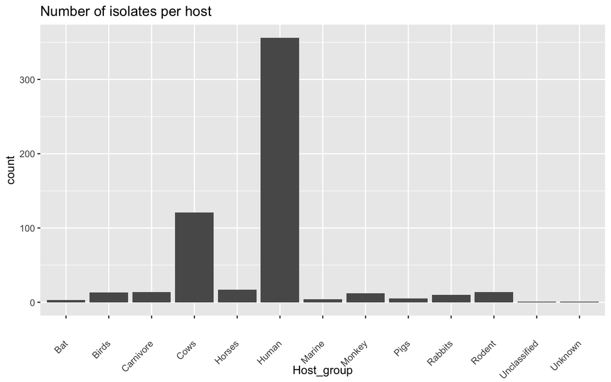

```r
isolate.per.host.ggplot <- ggplot(metadata.for.plotting, aes(x=Host_group)) + # load data into ggplot and define axes
  geom_bar() + #Plot a geometric bar
  ggtitle("Number of isolates per host") + # add a title
  theme(axis.text.x = element_text(angle = 45, vjust = 0.5, hjust=1)) # Rotate labels
isolate.per.host.ggplot
```

Now, let’s get to objective 2

# Objective 2: Summarizing datasets with barplots

At this point, you all of you should be have to obtain a filtered dataset with 571 tips.

## First, lets extract the relevant metadata from above (“metadata.filtered” object) to use in plots (using the dplyr package).

We need to extract the hosts that you will be working with. In this example, I am extracting “marine”, “bats”, and “monkeys”. However, how do we know what those host groups are named in the metadata?

As mentioned previously, we look at the unique names of the “Source.group”, which refers to the column with host groups in the metadata.

```r
unique(metadata.filtered$Source.group)
```

```
##  [1] "Human"        "Horses"       "Cows"         "Rabbits"      "Carnivore"
##  [6] "Birds"        "Bat"          "Rodent"       "Pigs"         "Unclassified"
## [11] "Marine"       "Monkey"       "Unknown"
```

We see that the groups we are looking for are called: **“Marine”, “Bat”, and “Monkey”**. The reason why I suggest doing this is because the spelling and case (upper or lower case) matters when extracting specific data from our metadata.

Now, let’s subset the metadata with the rows we want:

```r
metadata.marine.bats.monkey <- metadata.filtered %>% filter(Source.group==c("Marine", "Bat", "Monkey")) #extract values needed from filtered table
length(metadata.marine.bats.monkey$Number)
```

```
## [1] 6
```

As we see, this is not a great dataset because we only have 6 datapoints total.

Let’s look for a different group instead. Let’s find out how many **Carnivores, Rabbits and Cows** we have.

```r
metadata.carn.rabb.cows <- metadata.filtered %>% filter(Source.group==c("Carnivore", "Rabbits", "Cows")) #extract values needed from filtered table
length(metadata.carn.rabb.cows$Number)
```

```
## [1] 51
```

51 total, this is a better number to work with. So we will plot this dataset.

We plot using this new metadata. Let’s plot the number of isolates per host first:

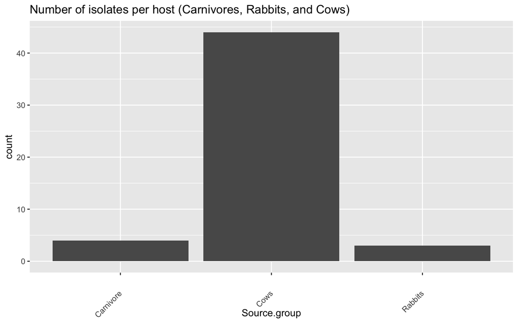

```r
isolate.per.host.ggplot.subset <- ggplot(metadata.carn.rabb.cows, aes(x=Source.group)) + # load data into ggplot and define axes
  geom_bar() + #Plot a geometric bar
  ggtitle("Number of isolates per host (Carnivores, Rabbits, and Cows)") + # add a title
  theme(axis.text.x = element_text(angle = 45, vjust = 0.5, hjust=1)) # Rotate labels
isolate.per.host.ggplot.subset
```

We see that the majority of isolates were obtained from cows infected with S. aureus.

In most cases, we want to sort these plots in descending (or ascending) order. To do so we use the **dplyr** package to summarise by count first, then plot and sort counts:

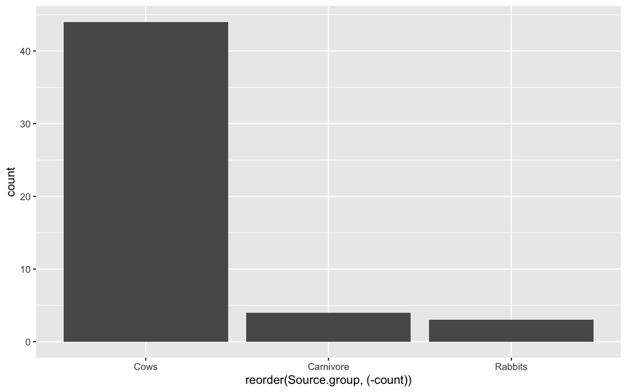

```r
metadata.carn.rabb.cows %>%
    dplyr::group_by(Source.group) %>%
    dplyr::summarise(count = n()) %>%
    ggplot(aes(x = reorder(Source.group,(-count)), y = count)) +
        geom_bar(stat = 'identity')
```

Now, how do we plot percentages?

We use a similar approach with packages such as **scales** and **tidyr** (to make our life easier):

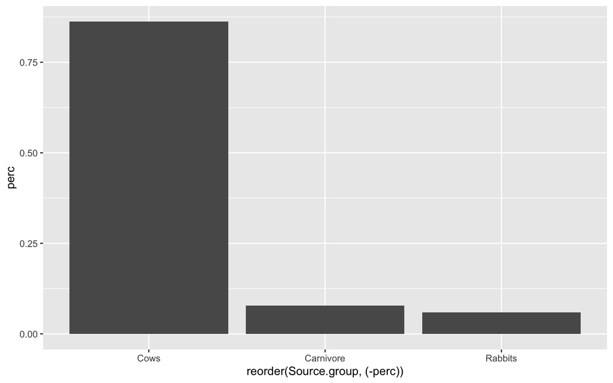

```r
metadata.carn.rabb.cows %>%
  dplyr::count(Source.group) %>%
  dplyr::mutate(perc = n / nrow(metadata.carn.rabb.cows)) -> metadata.carn.rabb.cows.2

ggplot(metadata.carn.rabb.cows.2, aes(x = reorder(Source.group,(-perc)), y = perc)) + geom_bar(stat = "identity")
```

Now we have percentages.

## Adding colors

Now, how do we color these bar plots?

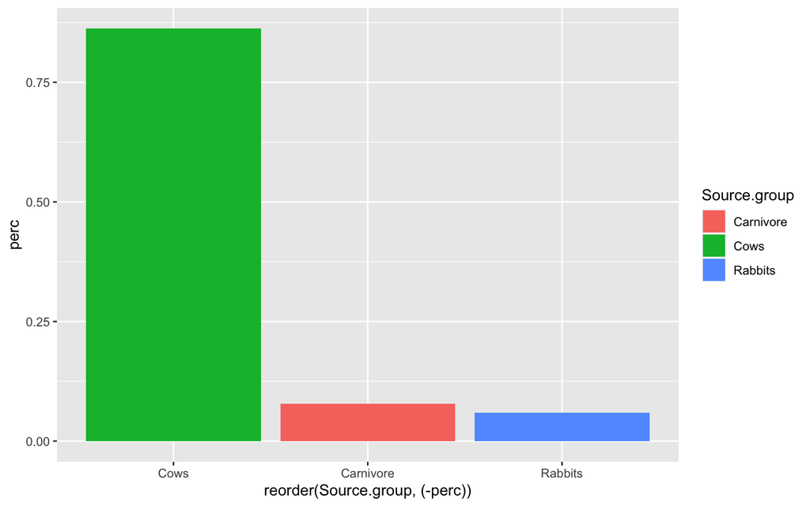

```r
metadata.carn.rabb.cows %>%
  dplyr::count(Source.group) %>%
  dplyr::mutate(perc = n / nrow(metadata.carn.rabb.cows)) -> metadata.carn.rabb.cows.2

ggplot(metadata.carn.rabb.cows.2, aes(x = reorder(Source.group,(-perc)), y = perc, fill=Source.group)) + geom_bar(stat = "identity")
```

The above code simply chooses the default colors from ggplot.

Now, how do you we choose our own collors?

There are many ways. You can choose your colors manually from the **r-base** palettes, or you can use a package such as “RColorBrewer”.

Here is an example using the **r-base**:

**1. Using the r-base colors**

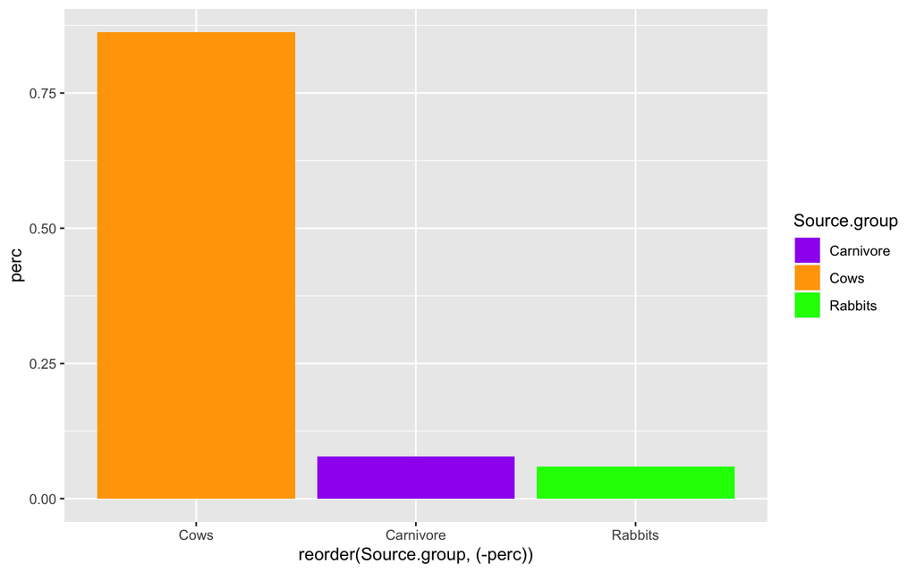

```r
metadata.carn.rabb.cows %>%
  dplyr::count(Source.group) %>%
  dplyr::mutate(perc = n / nrow(metadata.carn.rabb.cows)) -> metadata.carn.rabb.cows.2

ggplot(metadata.carn.rabb.cows.2, aes(x = reorder(Source.group,(-perc)), y = perc, fill=Source.group)) + scale_fill_manual(values = c("purple", "orange", "green")) +
geom_bar(stat = "identity")
```

**Note: If you are interested in using other palettes, please let Teddy know as soon as possible.**

Now, lets make a more complex plot, using at least two levels of our metadata. Let’s plot by **year** and by **Source.group**.

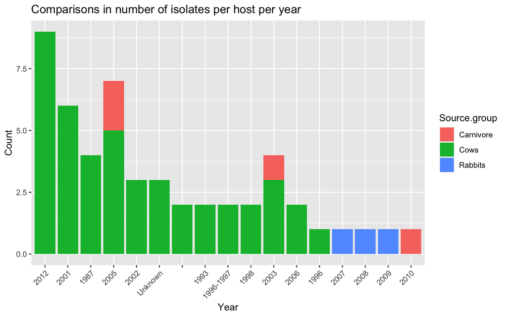

```r
metadata.carn.rabb.cows %>%
    dplyr::group_by(Source.group, Year) %>%
    dplyr::summarise(count = n()) %>%
    ggplot(aes(x = reorder(Year,(-count)), y = count, fill=Source.group)) +
        geom_bar(stat = 'identity') +
    theme(axis.text.x = element_text(angle = 45, vjust = 1, hjust=1)) +
   labs(
    title = "Comparisons in number of isolates per host per year",
    x = "Year",
    y = "Count"
    )
```

This will be useful if you want to plot several levels of the same data and visualize the results.

Here we see when the majority of these isolates were obtained.

## What about plotting the entire dataset with colors?

Let’s try with **logs** to make our plots look better:

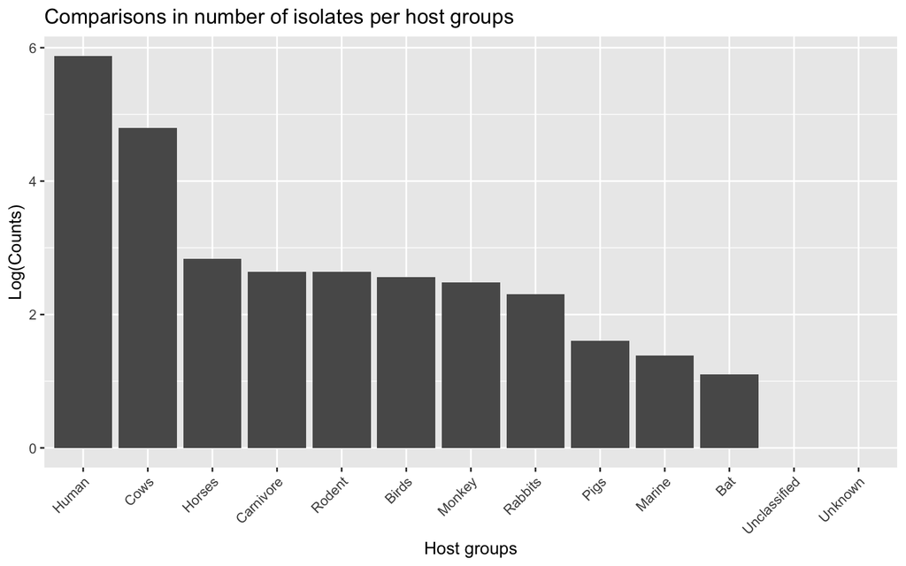

```r
metadata.filtered %>%
    dplyr::group_by(Source.group) %>%
    dplyr::summarise(count = n()) %>%
    ggplot(aes(x = reorder(Source.group,(-count)), y = log(count))) +
  geom_bar(stat = "identity") +
  theme(axis.text.x = element_text(angle = 45, vjust = 1, hjust=1)) +
   labs(
    title = "Comparisons in number of isolates per host groups",
    x = "Host groups",
    y = "Log(Counts)"
    )
```

This plot is easy to read and very informative because we used a different scale for counts (log).

Let’s add colors:

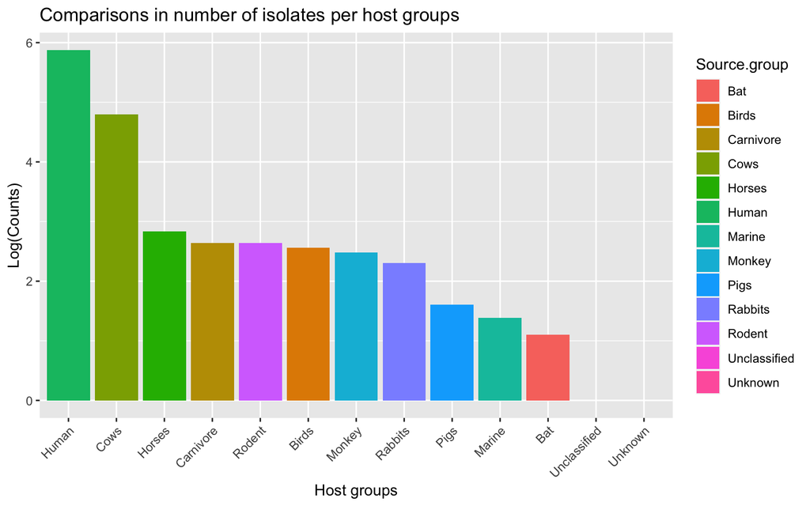

```r
metadata.filtered %>%
    dplyr::group_by(Source.group) %>%
    dplyr::summarise(count = n()) %>%
    ggplot(aes(x = reorder(Source.group,(-count)), y = log(count), fill=Source.group)) +
  geom_bar(stat = "identity") +
  theme(axis.text.x = element_text(angle = 45, vjust = 1, hjust=1)) +
   labs(
    title = "Comparisons in number of isolates per host groups",
    x = "Host groups",
    y = "Log(Counts)"
    )
```

This is much, much better. But the legend is not in the same order. To fix that:

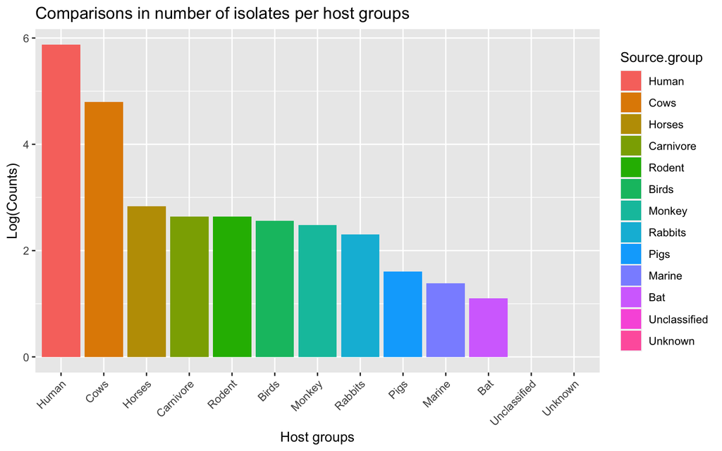

```r
metadata.filtered.2 <- metadata.filtered %>%
    dplyr::group_by(Source.group) %>%
    dplyr::summarise(count = n())

metadata.filtered.2$Source.group <- with(metadata.filtered.2, reorder(Source.group, -count))
    ggplot(metadata.filtered.2, aes(x =Source.group, y = log(count), fill=Source.group)) +
  geom_bar(stat = "identity") +
  theme(axis.text.x = element_text(angle = 45, vjust = 1, hjust=1)) +
   labs(
    title = "Comparisons in number of isolates per host groups",
    x = "Host groups",
    y = "Log(Counts)"
    )
```

This plot is publication-ready.